# A Market Segmentation and Purchase Drivers Process

T. Evgeniou

> **IMPORTANT**: Please make sure you create a copy of this file with a customized name, so that your work (e.g. answers to the questions) is not over-written when you pull the latest content from the course github. This is a **template process for market segmentation based on survey data**, using the [Boats cases A](http://inseaddataanalytics.github.io/INSEADAnalytics/Boats-A-prerelease.pdf) and [B](http://inseaddataanalytics.github.io/INSEADAnalytics/Boats-B-prerelease.pdf).

All material and code is available at the [INSEAD Data Analytics for Business](http://inseaddataanalytics.github.io/INSEADAnalytics/) website and github. Before starting, make sure you have pulled the [course files](https://github.com/InseadDataAnalytics/INSEADAnalytics) on your github repository. As always, you can use the `help` command in Rstudio to find out about any R function (e.g. type `help(list.files)` to learn what the R function `list.files` does).

# The Business Questions

This process can be used as a (starting) template for projects like the one described in the [Boats cases A](http://inseaddataanalytics.github.io/INSEADAnalytics/Boats-A-prerelease.pdf) and [B](http://inseaddataanalytics.github.io/INSEADAnalytics/Boats-B-prerelease.pdf). For example (but not only), in this case some of the business questions were:

- What are the main purchase drivers of the customers (and prospects) of this company?
- Are there different market segments? Which ones? Do the purchase drivers differ across segments?
- What (possibly market segment specific) product development or brand positioning strategy should the company follow in order to increase its sales?

See for example some of the analysis of this case in these slides: part 1 and part 2.

# The Process

The “high level” process template is split in 3 parts, corresponding to the course sessions 3-4, 5-6, and an optional last part:

1. *Part 1*: We use some of the survey questions (e.g. in this case the first 29 “attitude” questions) to find **key customer descriptors** (“factors”) using *dimensionality reduction* techniques described in the [Dimensionality Reduction](http://inseaddataanalytics.github.io/INSEADAnalytics/CourseSessions/Sessions23/FactorAnalysisReading.html) reading of Sessions 3-4.
2. *Part 2*: We use the selected customer descriptors to **segment the market** using *cluster analysis* techniques described in the [Cluster Analysis](http://inseaddataanalytics.github.io/INSEADAnalytics/CourseSessions/Sessions45/ClusterAnalysisReading.html) reading of Sessions 5-6.
3. *Part 3*: For the market segments we create, we will use *classification analysis* to classify people based on whether or not they have purchased a product and find what are the **key purchase drivers per segment**. For this part we will use [classification analysis](http://inseaddataanalytics.github.io/INSEADAnalytics/CourseSessions/Sessions67/ClassificationAnalysisReading.html) techniques.

Finally, we will use the results of this analysis to make business decisions e.g. about brand positioning, product development, etc depending on our market segments and key purchase drivers we find at the end of this process.

# The Data

First we load the data to use (see the raw .Rmd file to change the data file as needed):

```r
# Please ENTER the name of the file with the data used. The file should be a
# .csv with one row per observation (e.g. person) and one column per
# attribute. Do not add .csv at the end, make sure the data are numeric.
datafile_name = "../Sessions23/data/Boats.csv"

# Please enter the minimum number below which you would like not to print -
# this makes the readability of the tables easier. Default values are either
# 10e6 (to print everything) or 0.5. Try both to see the difference.
MIN_VALUE = 0.5

# Please enter the maximum number of observations to show in the report and
# slides.  DEFAULT is 10. If the number is large the report may be slow.
max_data_report = 10
```

# Part 1: Key Customer Characteristics

The code used here is along the lines of the code in the session 3-4 reading FactorAnalysisReading.Rmd. We follow the process described in the [Dimensionality Reduction](http://inseaddataanalytics.github.io/INSEADAnalytics/CourseSessions/Sessions23/FactorAnalysisReading.html) reading.

In this part we also become familiar with:

1. Some visualization tools;
2. Principal Component Analysis and Factor Analysis;
3. Introduction to machine learning methods;

(All user inputs for this part should be selected in the code chunk in the raw .Rmd file)

```r
# Please ENTER then original raw attributes to use.  Please use numbers, not
# column names, e.g. c(1:5, 7, 8) uses columns 1,2,3,4,5,7,8
factor_attributes_used = c(2:30)

# Please ENTER the selection criterions for the factors to use.  Choices:
# 'eigenvalue', 'variance', 'manual'
factor_selectionciterion = "manual"

# Please ENTER the desired minumum variance explained (Only used in case
# 'variance' is the factor selection criterion used).
minimum_variance_explained = 65  # between 1 and 100

# Please ENTER the number of factors to use (Only used in case 'manual' is
# the factor selection criterion used).
manual_numb_factors_used = 15

# Please ENTER the rotation eventually used (e.g. 'none', 'varimax',
# 'quatimax', 'promax', 'oblimin', 'simplimax', and 'cluster' - see
# help(principal)). Default is 'varimax'
rotation_used = "varimax"
```

## Steps 1-2: Check the Data

Start by some basic visual exploration of, say, a few data:

|  | Obs.01 | Obs.02 | Obs.03 | Obs.04 | Obs.05 | Obs.06 | Obs.07 | Obs.08 | Obs.09 | Obs.10 |
| --- | --- | --- | --- | --- | --- | --- | --- | --- | --- | --- |
| Q1.1 | 5 | 3 | 3 | 5 | 4 | 4 | 4 | 4 | 4 | 2 |
| Q1.2 | 1 | 2 | 1 | 2 | 2 | 2 | 3 | 3 | 3 | 5 |
| Q1.3 | 5 | 4 | 4 | 3 | 4 | 2 | 4 | 4 | 4 | 3 |
| Q1.4 | 5 | 4 | 4 | 4 | 5 | 4 | 4 | 4 | 4 | 2 |
| Q1.5 | 5 | 4 | 5 | 5 | 5 | 5 | 5 | 4 | 4 | 1 |
| Q1.6 | 5 | 4 | 4 | 5 | 4 | 5 | 5 | 5 | 4 | 3 |
| Q1.7 | 5 | 5 | 4 | 3 | 5 | 4 | 5 | 4 | 4 | 5 |
| Q1.8 | 3 | 3 | 2 | 3 | 4 | 3 | 5 | 4 | 3 | 4 |
| Q1.9 | 5 | 4 | 4 | 3 | 5 | 2 | 3 | 5 | 4 | 3 |
| Q1.10 | 4 | 4 | 3 | 4 | 4 | 4 | 1 | 3 | 3 | 4 |
| Q1.11 | 2 | 3 | 2 | 4 | 5 | 2 | 5 | 4 | 5 | 1 |
| Q1.12 | 1 | 2 | 2 | 2 | 1 | 2 | 3 | 1 | 1 | 3 |
| Q1.13 | 5 | 4 | 5 | 5 | 5 | 3 | 4 | 4 | 4 | 1 |
| Q1.14 | 5 | 4 | 5 | 5 | 4 | 4 | 4 | 4 | 4 | 4 |
| Q1.15 | 5 | 5 | 5 | 5 | 5 | 4 | 5 | 3 | 5 | 3 |
| Q1.16 | 4 | 3 | 4 | 4 | 5 | 4 | 4 | 3 | 4 | 2 |
| Q1.17 | 4 | 3 | 4 | 3 | 5 | 4 | 5 | 4 | 4 | 3 |
| Q1.18 | 5 | 5 | 4 | 5 | 5 | 4 | 4 | 4 | 4 | 5 |
| Q1.19 | 5 | 4 | 4 | 4 | 5 | 5 | 5 | 4 | 4 | 5 |
| Q1.20 | 4 | 3 | 3 | 3 | 4 | 3 | 4 | 3 | 4 | 4 |
| Q1.21 | 5 | 4 | 3 | 5 | 4 | 5 | 5 | 4 | 4 | 5 |
| Q1.22 | 5 | 4 | 5 | 4 | 4 | 5 | 5 | 4 | 4 | 4 |
| Q1.23 | 5 | 3 | 4 | 5 | 5 | 4 | 5 | 3 | 4 | 5 |
| Q1.24 | 5 | 4 | 4 | 3 | 4 | 5 | 5 | 5 | 4 | 4 |
| Q1.25 | 5 | 4 | 4 | 5 | 4 | 4 | 5 | 4 | 4 | 5 |
| Q1.26 | 5 | 4 | 5 | 4 | 5 | 4 | 5 | 5 | 5 | 4 |
| Q1.27 | 3 | 4 | 3 | 3 | 4 | 4 | 5 | 3 | 5 | 4 |
| Q1.28 | 4 | 4 | 3 | 3 | 4 | 4 | 5 | 3 | 5 | 4 |
| Q1.29 | 5 | 4 | 4 | 5 | 4 | 4 | 5 | 4 | 3 | 5 |

The data we use here have the following descriptive statistics:

|  | min | 25 percent | median | mean | 75 percent | max | std |
| --- | --- | --- | --- | --- | --- | --- | --- |
| Q1.1 | 1 | 4 | 4 | 4.03 | 5 | 5 | 0.82 |
| Q1.2 | 1 | 2 | 3 | 2.89 | 4 | 5 | 1.01 |
| Q1.3 | 1 | 2 | 3 | 3.12 | 4 | 5 | 1.02 |
| Q1.4 | 1 | 3 | 4 | 3.89 | 4 | 5 | 0.82 |
| Q1.5 | 1 | 3 | 4 | 3.55 | 4 | 5 | 0.93 |
| Q1.6 | 1 | 4 | 4 | 3.95 | 4 | 5 | 0.82 |
| Q1.7 | 1 | 3 | 4 | 3.67 | 4 | 5 | 0.90 |
| Q1.8 | 1 | 3 | 4 | 3.74 | 4 | 5 | 0.82 |
| Q1.9 | 1 | 2 | 3 | 2.89 | 4 | 5 | 1.08 |
| Q1.10 | 1 | 3 | 3 | 3.37 | 4 | 5 | 0.93 |
| Q1.11 | 1 | 3 | 4 | 3.46 | 4 | 5 | 1.15 |
| Q1.12 | 1 | 2 | 3 | 2.86 | 4 | 5 | 1.01 |
| Q1.13 | 1 | 2 | 3 | 3.02 | 4 | 5 | 0.98 |
| Q1.14 | 1 | 3 | 3 | 3.25 | 4 | 5 | 0.97 |
| Q1.15 | 1 | 3 | 4 | 3.63 | 4 | 5 | 0.89 |
| Q1.16 | 1 | 2 | 3 | 3.10 | 4 | 5 | 1.05 |
| Q1.17 | 1 | 2 | 3 | 3.08 | 4 | 5 | 0.98 |
| Q1.18 | 1 | 4 | 4 | 4.12 | 5 | 5 | 0.74 |
| Q1.19 | 1 | 4 | 4 | 4.20 | 5 | 5 | 0.72 |
| Q1.20 | 1 | 2 | 3 | 3.16 | 4 | 5 | 0.97 |
| Q1.21 | 1 | 4 | 4 | 4.25 | 5 | 5 | 0.73 |
| Q1.22 | 1 | 4 | 4 | 4.01 | 4 | 5 | 0.74 |
| Q1.23 | 1 | 3 | 4 | 3.56 | 4 | 5 | 1.02 |
| Q1.24 | 1 | 4 | 4 | 4.11 | 5 | 5 | 0.76 |
| Q1.25 | 1 | 3 | 4 | 3.79 | 4 | 5 | 0.91 |
| Q1.26 | 1 | 2 | 3 | 2.95 | 4 | 5 | 1.05 |
| Q1.27 | 1 | 2 | 3 | 3.16 | 4 | 5 | 1.05 |
| Q1.28 | 1 | 3 | 3 | 3.31 | 4 | 5 | 0.98 |
| Q1.29 | 1 | 4 | 4 | 4.03 | 4 | 5 | 0.73 |

## Step 3: Check Correlations

This is the correlation matrix of the customer responses to the 29 attitude questions - which are the only questions that we will use for the segmentation (see the case):

|  | Q1.1 | Q1.2 | Q1.3 | Q1.4 | Q1.5 | Q1.6 | Q1.7 | Q1.8 | Q1.9 | Q1.10 | Q1.11 | Q1.12 | Q1.13 | Q1.14 | Q1.15 | Q1.16 | Q1.17 | Q1.18 | Q1.19 | Q1.20 | Q1.21 | Q1.22 | Q1.23 | Q1.24 | Q1.25 | Q1.26 | Q1.27 | Q1.28 | Q1.29 |
| --- | --- | --- | --- | --- | --- | --- | --- | --- | --- | --- | --- | --- | --- | --- | --- | --- | --- | --- | --- | --- | --- | --- | --- | --- | --- | --- | --- | --- | --- |
| Q1.1 | 1.00 | 0.01 | 0.11 | 0.20 | 0.18 | 0.27 | 0.18 | 0.09 | 0.08 | 0.11 | 0.14 | -0.05 | 0.12 | 0.18 | 0.26 | 0.16 | 0.15 | 0.25 | 0.27 | 0.19 | 0.24 | 0.23 | 0.19 | 0.21 | 0.23 | 0.10 | 0.13 | 0.18 | 0.20 |
| Q1.2 | 0.01 | 1.00 | -0.03 | -0.21 | -0.21 | -0.04 | 0.02 | 0.20 | 0.09 | 0.16 | 0.04 | 0.37 | 0.01 | -0.03 | -0.08 | -0.02 | 0.04 | -0.04 | -0.04 | 0.05 | -0.10 | -0.08 | 0.00 | -0.08 | 0.01 | 0.07 | 0.05 | 0.02 | -0.03 |
| Q1.3 | 0.11 | -0.03 | 1.00 | 0.26 | 0.40 | 0.34 | 0.44 | -0.05 | 0.58 | 0.14 | 0.10 | -0.09 | 0.48 | 0.46 | 0.38 | 0.39 | 0.38 | 0.24 | 0.14 | 0.39 | 0.18 | 0.28 | 0.34 | 0.23 | 0.36 | 0.47 | 0.40 | 0.43 | 0.17 |
| Q1.4 | 0.20 | -0.21 | 0.26 | 1.00 | 0.37 | 0.20 | 0.18 | 0.00 | 0.17 | 0.10 | 0.06 | -0.16 | 0.27 | 0.29 | 0.30 | 0.18 | 0.17 | 0.18 | 0.19 | 0.18 | 0.18 | 0.23 | 0.16 | 0.23 | 0.22 | 0.19 | 0.17 | 0.21 | 0.19 |
| Q1.5 | 0.18 | -0.21 | 0.40 | 0.37 | 1.00 | 0.29 | 0.29 | -0.03 | 0.33 | 0.14 | 0.07 | -0.17 | 0.45 | 0.46 | 0.42 | 0.36 | 0.32 | 0.23 | 0.18 | 0.32 | 0.19 | 0.27 | 0.29 | 0.25 | 0.29 | 0.34 | 0.29 | 0.33 | 0.18 |
| Q1.6 | 0.27 | -0.04 | 0.34 | 0.20 | 0.29 | 1.00 | 0.55 | 0.04 | 0.35 | 0.12 | 0.15 | -0.12 | 0.29 | 0.31 | 0.31 | 0.27 | 0.24 | 0.44 | 0.36 | 0.35 | 0.42 | 0.41 | 0.32 | 0.37 | 0.42 | 0.31 | 0.34 | 0.39 | 0.27 |
| Q1.7 | 0.18 | 0.02 | 0.44 | 0.18 | 0.29 | 0.55 | 1.00 | -0.01 | 0.49 | 0.12 | 0.12 | -0.11 | 0.35 | 0.36 | 0.34 | 0.31 | 0.29 | 0.40 | 0.28 | 0.36 | 0.33 | 0.39 | 0.30 | 0.33 | 0.42 | 0.39 | 0.37 | 0.40 | 0.24 |
| Q1.8 | 0.09 | 0.20 | -0.05 | 0.00 | -0.03 | 0.04 | -0.01 | 1.00 | -0.09 | 0.09 | 0.14 | 0.24 | -0.05 | -0.02 | 0.06 | 0.02 | 0.05 | 0.07 | 0.09 | 0.04 | 0.06 | 0.05 | 0.10 | 0.02 | 0.10 | -0.04 | 0.03 | 0.05 | 0.10 |
| Q1.9 | 0.08 | 0.09 | 0.58 | 0.17 | 0.33 | 0.35 | 0.49 | -0.09 | 1.00 | 0.14 | 0.06 | -0.04 | 0.48 | 0.43 | 0.33 | 0.39 | 0.37 | 0.22 | 0.07 | 0.37 | 0.14 | 0.23 | 0.29 | 0.23 | 0.32 | 0.50 | 0.40 | 0.40 | 0.11 |
| Q1.10 | 0.11 | 0.16 | 0.14 | 0.10 | 0.14 | 0.12 | 0.12 | 0.09 | 0.14 | 1.00 | -0.09 | 0.12 | 0.16 | 0.11 | 0.11 | -0.03 | -0.03 | 0.14 | 0.09 | 0.10 | 0.08 | 0.09 | 0.07 | 0.13 | 0.08 | 0.13 | 0.08 | 0.07 | 0.05 |
| Q1.11 | 0.14 | 0.04 | 0.10 | 0.06 | 0.07 | 0.15 | 0.12 | 0.14 | 0.06 | -0.09 | 1.00 | 0.09 | 0.08 | 0.13 | 0.20 | 0.32 | 0.31 | 0.11 | 0.12 | 0.25 | 0.13 | 0.17 | 0.19 | 0.08 | 0.25 | 0.09 | 0.16 | 0.18 | 0.17 |
| Q1.12 | -0.05 | 0.37 | -0.09 | -0.16 | -0.17 | -0.12 | -0.11 | 0.24 | -0.04 | 0.12 | 0.09 | 1.00 | -0.11 | -0.17 | -0.17 | -0.02 | 0.02 | -0.12 | -0.09 | 0.01 | -0.17 | -0.11 | -0.03 | -0.17 | -0.05 | -0.06 | 0.00 | -0.01 | -0.04 |
| Q1.13 | 0.12 | 0.01 | 0.48 | 0.27 | 0.45 | 0.29 | 0.35 | -0.05 | 0.48 | 0.16 | 0.08 | -0.11 | 1.00 | 0.64 | 0.46 | 0.43 | 0.43 | 0.20 | 0.11 | 0.39 | 0.14 | 0.23 | 0.32 | 0.20 | 0.32 | 0.48 | 0.40 | 0.40 | 0.19 |
| Q1.14 | 0.18 | -0.03 | 0.46 | 0.29 | 0.46 | 0.31 | 0.36 | -0.02 | 0.43 | 0.11 | 0.13 | -0.17 | 0.64 | 1.00 | 0.50 | 0.43 | 0.40 | 0.25 | 0.18 | 0.41 | 0.21 | 0.29 | 0.36 | 0.21 | 0.35 | 0.46 | 0.39 | 0.40 | 0.21 |
| Q1.15 | 0.26 | -0.08 | 0.38 | 0.30 | 0.42 | 0.31 | 0.34 | 0.06 | 0.33 | 0.11 | 0.20 | -0.17 | 0.46 | 0.50 | 1.00 | 0.41 | 0.39 | 0.32 | 0.26 | 0.41 | 0.21 | 0.33 | 0.35 | 0.27 | 0.43 | 0.37 | 0.35 | 0.38 | 0.24 |
| Q1.16 | 0.16 | -0.02 | 0.39 | 0.18 | 0.36 | 0.27 | 0.31 | 0.02 | 0.39 | -0.03 | 0.32 | -0.02 | 0.43 | 0.43 | 0.41 | 1.00 | 0.63 | 0.20 | 0.14 | 0.52 | 0.16 | 0.30 | 0.40 | 0.19 | 0.39 | 0.40 | 0.48 | 0.50 | 0.20 |
| Q1.17 | 0.15 | 0.04 | 0.38 | 0.17 | 0.32 | 0.24 | 0.29 | 0.05 | 0.37 | -0.03 | 0.31 | 0.02 | 0.43 | 0.40 | 0.39 | 0.63 | 1.00 | 0.17 | 0.12 | 0.45 | 0.13 | 0.26 | 0.36 | 0.15 | 0.36 | 0.40 | 0.44 | 0.46 | 0.21 |
| Q1.18 | 0.25 | -0.04 | 0.24 | 0.18 | 0.23 | 0.44 | 0.40 | 0.07 | 0.22 | 0.14 | 0.11 | -0.12 | 0.20 | 0.25 | 0.32 | 0.20 | 0.17 | 1.00 | 0.49 | 0.28 | 0.47 | 0.44 | 0.29 | 0.42 | 0.37 | 0.24 | 0.25 | 0.31 | 0.30 |
| Q1.19 | 0.27 | -0.04 | 0.14 | 0.19 | 0.18 | 0.36 | 0.28 | 0.09 | 0.07 | 0.09 | 0.12 | -0.09 | 0.11 | 0.18 | 0.26 | 0.14 | 0.12 | 0.49 | 1.00 | 0.21 | 0.44 | 0.38 | 0.24 | 0.37 | 0.32 | 0.14 | 0.18 | 0.23 | 0.28 |
| Q1.20 | 0.19 | 0.05 | 0.39 | 0.18 | 0.32 | 0.35 | 0.36 | 0.04 | 0.37 | 0.10 | 0.25 | 0.01 | 0.39 | 0.41 | 0.41 | 0.52 | 0.45 | 0.28 | 0.21 | 1.00 | 0.23 | 0.33 | 0.40 | 0.24 | 0.41 | 0.40 | 0.50 | 0.52 | 0.25 |
| Q1.21 | 0.24 | -0.10 | 0.18 | 0.18 | 0.19 | 0.42 | 0.33 | 0.06 | 0.14 | 0.08 | 0.13 | -0.17 | 0.14 | 0.21 | 0.21 | 0.16 | 0.13 | 0.47 | 0.44 | 0.23 | 1.00 | 0.42 | 0.24 | 0.42 | 0.30 | 0.15 | 0.24 | 0.26 | 0.29 |
| Q1.22 | 0.23 | -0.08 | 0.28 | 0.23 | 0.27 | 0.41 | 0.39 | 0.05 | 0.23 | 0.09 | 0.17 | -0.11 | 0.23 | 0.29 | 0.33 | 0.30 | 0.26 | 0.44 | 0.38 | 0.33 | 0.42 | 1.00 | 0.34 | 0.38 | 0.37 | 0.23 | 0.35 | 0.38 | 0.34 |
| Q1.23 | 0.19 | 0.00 | 0.34 | 0.16 | 0.29 | 0.32 | 0.30 | 0.10 | 0.29 | 0.07 | 0.19 | -0.03 | 0.32 | 0.36 | 0.35 | 0.40 | 0.36 | 0.29 | 0.24 | 0.40 | 0.24 | 0.34 | 1.00 | 0.23 | 0.32 | 0.33 | 0.39 | 0.44 | 0.23 |
| Q1.24 | 0.21 | -0.08 | 0.23 | 0.23 | 0.25 | 0.37 | 0.33 | 0.02 | 0.23 | 0.13 | 0.08 | -0.17 | 0.20 | 0.21 | 0.27 | 0.19 | 0.15 | 0.42 | 0.37 | 0.24 | 0.42 | 0.38 | 0.23 | 1.00 | 0.31 | 0.21 | 0.24 | 0.25 | 0.27 |
| Q1.25 | 0.23 | 0.01 | 0.36 | 0.22 | 0.29 | 0.42 | 0.42 | 0.10 | 0.32 | 0.08 | 0.25 | -0.05 | 0.32 | 0.35 | 0.43 | 0.39 | 0.36 | 0.37 | 0.32 | 0.41 | 0.30 | 0.37 | 0.32 | 0.31 | 1.00 | 0.34 | 0.35 | 0.40 | 0.23 |
| Q1.26 | 0.10 | 0.07 | 0.47 | 0.19 | 0.34 | 0.31 | 0.39 | -0.04 | 0.50 | 0.13 | 0.09 | -0.06 | 0.48 | 0.46 | 0.37 | 0.40 | 0.40 | 0.24 | 0.14 | 0.40 | 0.15 | 0.23 | 0.33 | 0.21 | 0.34 | 1.00 | 0.45 | 0.47 | 0.15 |
| Q1.27 | 0.13 | 0.05 | 0.40 | 0.17 | 0.29 | 0.34 | 0.37 | 0.03 | 0.40 | 0.08 | 0.16 | 0.00 | 0.40 | 0.39 | 0.35 | 0.48 | 0.44 | 0.25 | 0.18 | 0.50 | 0.24 | 0.35 | 0.39 | 0.24 | 0.35 | 0.45 | 1.00 | 0.62 | 0.23 |
| Q1.28 | 0.18 | 0.02 | 0.43 | 0.21 | 0.33 | 0.39 | 0.40 | 0.05 | 0.40 | 0.07 | 0.18 | -0.01 | 0.40 | 0.40 | 0.38 | 0.50 | 0.46 | 0.31 | 0.23 | 0.52 | 0.26 | 0.38 | 0.44 | 0.25 | 0.40 | 0.47 | 0.62 | 1.00 | 0.26 |
| Q1.29 | 0.20 | -0.03 | 0.17 | 0.19 | 0.18 | 0.27 | 0.24 | 0.10 | 0.11 | 0.05 | 0.17 | -0.04 | 0.19 | 0.21 | 0.24 | 0.20 | 0.21 | 0.30 | 0.28 | 0.25 | 0.29 | 0.34 | 0.23 | 0.27 | 0.23 | 0.15 | 0.23 | 0.26 | 1.00 |

**Questions**

1. Do you see any high correlations between the responses? Do they make sense?
2. What do these correlations imply?

**Answers:**

## Step 4: Choose number of factors

Clearly the survey asked many redundant questions (can you think some reasons why?), so we may be able to actually “group” these 29 attitude questions into only a few “key factors”. This not only will simplify the data, but will also greatly facilitate our understanding of the customers.

To do so, we use methods called [Principal Component Analysis](https://en.wikipedia.org/wiki/Principal_component_analysis) and [factor analysis](https://en.wikipedia.org/wiki/Factor_analysis) as also discussed in the [Dimensionality Reduction readings](http://inseaddataanalytics.github.io/INSEADAnalytics/CourseSessions/Sessions23/FactorAnalysisReading.html). We can use two different R commands for this (they make slightly different information easily available as output): the command `principal` (check `help(principal)` from R package [psych](http://personality-project.org/r/psych/)), and the command `PCA` from R package [FactoMineR](http://factominer.free.fr) - there are more packages and commands for this, as these methods are very widely used.

Let’s look at the **variance explained** as well as the **eigenvalues** (see session readings):

|  | Eigenvalue | Pct of explained variance | Cumulative pct of explained variance |
| --- | --- | --- | --- |
| Component 1 | 8.43 | 29.08 | 29.08 |
| Component 2 | 2.33 | 8.05 | 37.12 |
| Component 3 | 1.86 | 6.42 | 43.55 |
| Component 4 | 1.46 | 5.03 | 48.57 |
| Component 5 | 1.21 | 4.16 | 52.74 |
| Component 6 | 0.90 | 3.10 | 55.84 |
| Component 7 | 0.82 | 2.82 | 58.65 |
| Component 8 | 0.79 | 2.71 | 61.36 |
| Component 9 | 0.78 | 2.69 | 64.05 |
| Component 10 | 0.74 | 2.56 | 66.61 |
| Component 11 | 0.69 | 2.37 | 68.98 |
| Component 12 | 0.65 | 2.25 | 71.23 |
| Component 13 | 0.65 | 2.23 | 73.47 |
| Component 14 | 0.62 | 2.13 | 75.60 |
| Component 15 | 0.61 | 2.10 | 77.70 |
| Component 16 | 0.58 | 1.99 | 79.69 |
| Component 17 | 0.56 | 1.94 | 81.62 |
| Component 18 | 0.54 | 1.85 | 83.47 |
| Component 19 | 0.52 | 1.81 | 85.28 |
| Component 20 | 0.51 | 1.76 | 87.04 |
| Component 21 | 0.50 | 1.72 | 88.77 |
| Component 22 | 0.49 | 1.69 | 90.45 |
| Component 23 | 0.46 | 1.59 | 92.04 |
| Component 24 | 0.46 | 1.57 | 93.61 |
| Component 25 | 0.41 | 1.42 | 95.03 |
| Component 26 | 0.38 | 1.32 | 96.36 |
| Component 27 | 0.37 | 1.28 | 97.63 |
| Component 28 | 0.35 | 1.22 | 98.85 |
| Component 29 | 0.33 | 1.15 | 100.00 |

[interactive chart not shown]

**Questions:**

1. Can you explain what this table and the plot are? What do they indicate? What can we learn from these?
2. Why does the plot have this specific shape? Could the plotted line be increasing?
3. What characteristics of these results would we prefer to see? Why?

**Answers**

## Step 5: Interpret the factors

Let’s now see how the “top factors” look like.

To better visualize them, we will use what is called a “rotation”. There are many rotations methods. In this case we selected the varimax rotation. For our data, the 15 selected factors look as follows after this rotation:

|  | Comp.1 | Comp.2 | Comp.3 | Comp.4 | Comp.5 | Comp.6 | Comp.7 | Comp.8 | Comp.9 | Comp.10 | Comp.11 | Comp.12 | Comp.13 | Comp.14 | Comp.15 |
| --- | --- | --- | --- | --- | --- | --- | --- | --- | --- | --- | --- | --- | --- | --- | --- |
| Q1.27 | 0.81 | 0.18 | 0.11 | 0.18 | 0.03 | -0.02 | -0.04 | 0.03 | -0.02 | -0.01 | 0.07 | 0.04 | 0.05 | 0.05 | 0.03 |
| Q1.28 | 0.76 | 0.18 | 0.18 | 0.21 | 0.00 | -0.01 | 0.00 | -0.01 | 0.05 | 0.03 | 0.07 | 0.03 | 0.11 | 0.14 | -0.01 |
| Q1.20 | 0.65 | 0.22 | 0.13 | 0.14 | -0.03 | 0.16 | 0.04 | 0.11 | 0.21 | 0.09 | 0.08 | -0.03 | -0.02 | 0.10 | 0.03 |
| Q1.16 | 0.55 | 0.39 | 0.01 | 0.09 | -0.14 | 0.27 | 0.15 | -0.16 | 0.20 | 0.08 | 0.02 | -0.03 | -0.08 | 0.12 | 0.25 |
| Q1.17 | 0.48 | 0.43 | -0.02 | 0.08 | -0.06 | 0.25 | 0.22 | -0.21 | 0.20 | 0.08 | 0.06 | -0.01 | -0.05 | 0.09 | 0.24 |
| Q1.26 | 0.44 | 0.44 | 0.07 | 0.31 | 0.25 | -0.03 | -0.10 | 0.04 | 0.08 | -0.05 | -0.05 | -0.10 | 0.15 | 0.11 | 0.03 |
| Q1.23 | 0.32 | 0.18 | 0.20 | 0.14 | -0.03 | 0.09 | -0.03 | 0.02 | 0.04 | 0.07 | 0.06 | 0.08 | 0.00 | 0.84 | 0.02 |
| Q1.22 | 0.29 | 0.03 | 0.46 | 0.22 | -0.17 | 0.08 | -0.03 | 0.07 | 0.09 | 0.04 | 0.28 | 0.01 | 0.07 | 0.17 | 0.16 |
| Q1.25 | 0.29 | 0.12 | 0.30 | 0.32 | 0.00 | 0.15 | -0.01 | 0.00 | 0.65 | 0.04 | 0.02 | 0.09 | 0.09 | -0.02 | 0.05 |
| Q1.6 | 0.25 | 0.07 | 0.43 | 0.60 | -0.14 | 0.08 | -0.08 | 0.08 | 0.03 | 0.20 | 0.08 | 0.09 | -0.02 | -0.04 | -0.06 |
| Q1.13 | 0.25 | 0.78 | 0.05 | 0.20 | 0.03 | 0.00 | -0.06 | 0.08 | 0.05 | 0.00 | 0.08 | -0.03 | 0.06 | 0.02 | 0.02 |
| Q1.14 | 0.24 | 0.77 | 0.16 | 0.16 | 0.02 | 0.07 | -0.16 | 0.03 | 0.05 | 0.05 | 0.07 | 0.02 | 0.08 | 0.06 | -0.08 |
| Q1.9 | 0.23 | 0.40 | -0.04 | 0.65 | 0.12 | -0.02 | 0.06 | 0.02 | 0.04 | -0.03 | -0.03 | -0.13 | 0.05 | 0.12 | 0.21 |
| Q1.15 | 0.22 | 0.48 | 0.15 | 0.08 | -0.07 | 0.09 | -0.19 | 0.09 | 0.53 | 0.14 | 0.11 | 0.08 | 0.08 | 0.13 | 0.06 |
| Q1.3 | 0.21 | 0.42 | 0.02 | 0.57 | -0.04 | 0.02 | 0.06 | 0.02 | 0.07 | -0.06 | 0.01 | -0.08 | 0.20 | 0.23 | 0.12 |
| Q1.7 | 0.20 | 0.15 | 0.27 | 0.74 | -0.01 | 0.02 | -0.06 | 0.03 | 0.16 | 0.06 | 0.11 | 0.01 | -0.03 | 0.02 | 0.03 |
| Q1.21 | 0.17 | 0.07 | 0.71 | 0.16 | -0.09 | 0.16 | -0.18 | 0.02 | -0.27 | 0.07 | 0.07 | 0.11 | 0.02 | -0.07 | 0.16 |
| Q1.5 | 0.14 | 0.58 | 0.14 | 0.15 | -0.49 | -0.05 | 0.12 | 0.11 | 0.07 | 0.12 | -0.01 | 0.02 | 0.15 | 0.07 | 0.12 |
| Q1.29 | 0.13 | 0.11 | 0.21 | 0.07 | 0.00 | 0.06 | 0.01 | -0.01 | 0.04 | 0.07 | 0.92 | 0.04 | 0.06 | 0.04 | 0.06 |
| Q1.11 | 0.12 | 0.04 | 0.08 | 0.03 | 0.03 | 0.94 | 0.04 | -0.05 | 0.09 | 0.04 | 0.06 | 0.06 | 0.03 | 0.06 | -0.01 |
| Q1.24 | 0.12 | 0.04 | 0.41 | 0.17 | -0.01 | -0.01 | -0.17 | 0.10 | 0.04 | 0.06 | 0.10 | 0.03 | 0.11 | 0.02 | 0.77 |
| Q1.18 | 0.10 | 0.11 | 0.71 | 0.19 | 0.00 | -0.02 | -0.02 | 0.06 | 0.17 | 0.05 | 0.09 | 0.01 | -0.01 | 0.10 | 0.13 |
| Q1.4 | 0.09 | 0.20 | 0.11 | 0.06 | -0.17 | 0.03 | -0.04 | 0.04 | 0.07 | 0.10 | 0.07 | 0.02 | 0.90 | 0.01 | 0.07 |
| Q1.1 | 0.07 | 0.06 | 0.18 | 0.06 | 0.03 | 0.05 | -0.03 | 0.04 | 0.06 | 0.94 | 0.07 | 0.03 | 0.09 | 0.05 | 0.04 |
| Q1.12 | 0.06 | -0.13 | -0.07 | -0.03 | 0.23 | 0.05 | 0.85 | 0.11 | -0.06 | -0.03 | 0.01 | 0.14 | -0.03 | -0.02 | -0.11 |
| Q1.19 | 0.04 | 0.08 | 0.82 | -0.03 | 0.04 | -0.02 | 0.07 | -0.03 | 0.20 | 0.10 | 0.05 | -0.03 | 0.11 | 0.11 | 0.01 |
| Q1.2 | 0.03 | 0.03 | -0.04 | 0.03 | 0.82 | 0.02 | 0.28 | 0.10 | -0.01 | 0.06 | -0.01 | 0.13 | -0.14 | -0.01 | 0.02 |
| Q1.10 | 0.02 | 0.10 | 0.06 | 0.06 | 0.06 | -0.05 | 0.10 | 0.95 | 0.03 | 0.04 | 0.00 | 0.02 | 0.03 | 0.02 | 0.06 |
| Q1.8 | 0.01 | -0.02 | 0.05 | -0.04 | 0.10 | 0.06 | 0.13 | 0.02 | 0.06 | 0.03 | 0.04 | 0.96 | 0.01 | 0.06 | 0.02 |

To better visualize and interpret the factors we often “suppress” loadings with small values, e.g. with absolute values smaller than 0.5. In this case our factors look as follows after suppressing the small numbers:

|  | Comp.1 | Comp.2 | Comp.3 | Comp.4 | Comp.5 | Comp.6 | Comp.7 | Comp.8 | Comp.9 | Comp.10 | Comp.11 | Comp.12 | Comp.13 | Comp.14 | Comp.15 |
| --- | --- | --- | --- | --- | --- | --- | --- | --- | --- | --- | --- | --- | --- | --- | --- |
| Q1.27 | 0.81 |  |  |  |  |  |  |  |  |  |  |  |  |  |  |
| Q1.28 | 0.76 |  |  |  |  |  |  |  |  |  |  |  |  |  |  |
| Q1.20 | 0.65 |  |  |  |  |  |  |  |  |  |  |  |  |  |  |
| Q1.16 | 0.55 |  |  |  |  |  |  |  |  |  |  |  |  |  |  |
| Q1.17 |  |  |  |  |  |  |  |  |  |  |  |  |  |  |  |
| Q1.26 |  |  |  |  |  |  |  |  |  |  |  |  |  |  |  |
| Q1.23 |  |  |  |  |  |  |  |  |  |  |  |  |  | 0.84 |  |
| Q1.22 |  |  |  |  |  |  |  |  |  |  |  |  |  |  |  |
| Q1.25 |  |  |  |  |  |  |  |  | 0.65 |  |  |  |  |  |  |
| Q1.6 |  |  |  | 0.60 |  |  |  |  |  |  |  |  |  |  |  |
| Q1.13 |  | 0.78 |  |  |  |  |  |  |  |  |  |  |  |  |  |
| Q1.14 |  | 0.77 |  |  |  |  |  |  |  |  |  |  |  |  |  |
| Q1.9 |  |  |  | 0.65 |  |  |  |  |  |  |  |  |  |  |  |
| Q1.15 |  |  |  |  |  |  |  |  | 0.53 |  |  |  |  |  |  |
| Q1.3 |  |  |  | 0.57 |  |  |  |  |  |  |  |  |  |  |  |
| Q1.7 |  |  |  | 0.74 |  |  |  |  |  |  |  |  |  |  |  |
| Q1.21 |  |  | 0.71 |  |  |  |  |  |  |  |  |  |  |  |  |
| Q1.5 |  | 0.58 |  |  |  |  |  |  |  |  |  |  |  |  |  |
| Q1.29 |  |  |  |  |  |  |  |  |  |  | 0.92 |  |  |  |  |
| Q1.11 |  |  |  |  |  | 0.94 |  |  |  |  |  |  |  |  |  |
| Q1.24 |  |  |  |  |  |  |  |  |  |  |  |  |  |  | 0.77 |
| Q1.18 |  |  | 0.71 |  |  |  |  |  |  |  |  |  |  |  |  |
| Q1.4 |  |  |  |  |  |  |  |  |  |  |  |  | 0.9 |  |  |
| Q1.1 |  |  |  |  |  |  |  |  |  | 0.94 |  |  |  |  |  |
| Q1.12 |  |  |  |  |  |  | 0.85 |  |  |  |  |  |  |  |  |
| Q1.19 |  |  | 0.82 |  |  |  |  |  |  |  |  |  |  |  |  |
| Q1.2 |  |  |  |  | 0.82 |  |  |  |  |  |  |  |  |  |  |
| Q1.10 |  |  |  |  |  |  |  | 0.95 |  |  |  |  |  |  |  |
| Q1.8 |  |  |  |  |  |  |  |  |  |  |  | 0.96 |  |  |  |

**Questions**

1. What do the first couple of factors mean? Do they make business sense?
2. How many factors should we choose for this data/customer base? Please try a few and explain your final choice based on a) statistical arguments, b) on interpretation arguments, c) on business arguments (**you need to consider all three types of arguments**)
3. How would you interpret the factors you selected?
4. What lessons about data science do you learn when doing this analysis? Please comment.

**Answers**

## Step 6: Save factor scores

We can now either replace all initial variables used in this part with the factors scores or just select one of the initial variables for each of the selected factors in order to represent that factor. Here is how the factor scores are for the first few respondents:

|  | Obs.01 | Obs.02 | Obs.03 | Obs.04 | Obs.05 | Obs.06 | Obs.07 | Obs.08 | Obs.09 | Obs.10 |
| --- | --- | --- | --- | --- | --- | --- | --- | --- | --- | --- |
| DV (Factor) 1 | -0.34 | 0.14 | -0.47 | -0.67 | 0.26 | 1.23 | 1.43 | -0.55 | 1.82 | 1.13 |
| DV (Factor) 2 | 1.81 | 0.89 | 2.36 | 2.39 | 1.99 | 0.41 | 0.81 | 1.10 | 0.82 | -1.43 |
| DV (Factor) 3 | 0.70 | -0.04 | -0.69 | 0.64 | -0.07 | 1.28 | 0.75 | -0.67 | -0.69 | 1.56 |
| DV (Factor) 4 | 1.38 | 1.00 | 0.26 | -0.43 | 0.37 | -0.90 | 0.61 | 1.74 | 0.06 | 0.13 |
| DV (Factor) 5 | -1.05 | -0.30 | -1.45 | -0.91 | -0.41 | -1.47 | -0.03 | 0.78 | 0.72 | 3.24 |
| DV (Factor) 6 | -1.31 | -0.65 | -1.34 | 0.65 | 0.98 | -1.19 | 0.47 | 0.43 | 0.98 | -2.12 |
| DV (Factor) 7 | -1.11 | -1.01 | -0.22 | -0.89 | -0.79 | -0.40 | 0.00 | -1.43 | -2.10 | -0.86 |
| DV (Factor) 8 | 0.16 | 0.74 | -0.41 | 0.80 | 0.09 | 0.51 | -2.61 | -0.73 | -0.19 | 0.20 |
| DV (Factor) 9 | 0.75 | 1.00 | 1.45 | 0.31 | 0.85 | -0.25 | 0.31 | -0.62 | 0.37 | 1.10 |
| DV (Factor) 10 | 0.63 | -1.57 | -1.35 | 1.02 | -0.40 | 0.15 | -0.41 | -0.13 | -0.15 | -3.05 |
| DV (Factor) 11 | 0.81 | 0.07 | 0.42 | 0.92 | -0.73 | -0.32 | 0.80 | -0.37 | -1.72 | 1.24 |
| DV (Factor) 12 | -0.93 | -0.71 | -2.01 | -0.59 | -0.12 | -0.51 | 1.78 | 0.32 | -0.80 | 0.00 |
| DV (Factor) 13 | 0.59 | -0.04 | -0.35 | -0.76 | 0.62 | -0.61 | 0.10 | 0.20 | 0.26 | -1.81 |
| DV (Factor) 14 | 1.01 | -0.63 | 0.72 | 0.58 | 1.22 | -0.44 | 0.36 | -0.73 | 0.21 | 1.46 |
| DV (Factor) 15 | 0.52 | -0.58 | -0.12 | -2.26 | 0.24 | 0.61 | 0.26 | 1.42 | -0.26 | -0.77 |

**Questions**

1. Can you describe some of the people using the new derived variables (factor scores)?
2. Which of the 29 initial variables would you select to represent each of the factors you selected?

**Answers**

# Part 2: Customer Segmentation

The code used here is along the lines of the code in the session 5-6 reading ClusterAnalysisReading.Rmd. We follow the process described in the [Cluster Analysis](http://inseaddataanalytics.github.io/INSEADAnalytics/CourseSessions/Sessions45/ClusterAnalysisReading.html) reading.

In this part we also become familiar with:

1. Some clustering Methods;
2. How these tools can be used in practice.

A key family of methods used for segmentation is what is called **clustering methods**. This is a very important problem in statistics and **machine learning**, used in all sorts of applications such as in [Amazon’s pioneer work on recommender systems](http://www.cs.umd.edu/~samir/498/Amazon-Recommendations.pdf). There are many *mathematical methods* for clustering. We will use two very standard methods, **hierarchical clustering** and **k-means**. While the “math” behind all these methods can be complex, the R functions used are relatively simple to use, as we will see.

(All user inputs for this part should be selected in the code chunk in the raw .Rmd file)

```r
# Please ENTER then original raw attributes to use for the segmentation (the
# 'segmentation attributes') Please use numbers, not column names, e.g.
# c(1:5, 7, 8) uses columns 1,2,3,4,5,7,8
segmentation_attributes_used = c(28, 29, 21, 17)  #c(10,19,5,12,3)

# Please ENTER then original raw attributes to use for the profiling of the
# segments (the 'profiling attributes') Please use numbers, not column
# names, e.g. c(1:5, 7, 8) uses columns 1,2,3,4,5,7,8
profile_attributes_used = c(2:82)

# Please ENTER the number of clusters to eventually use for this report
numb_clusters_used = 4  # for boats possibly use 5, for Mall_Visits use 3

# Please enter the method to use for the segmentation:
profile_with = "hclust"  #  'hclust' or 'kmeans'

# Please ENTER the distance metric eventually used for the clustering in
# case of hierarchical clustering (e.g. 'euclidean', 'maximum', 'manhattan',
# 'canberra', 'binary' or 'minkowski' - see help(dist)).  DEFAULT is
# 'euclidean'
distance_used = "euclidean"

# Please ENTER the hierarchical clustering method to use (options are:
# 'ward', 'single', 'complete', 'average', 'mcquitty', 'median' or
# 'centroid').  DEFAULT is 'ward'
hclust_method = "ward.D"

# Please ENTER the kmeans clustering method to use (options are:
# 'Hartigan-Wong', 'Lloyd', 'Forgy', 'MacQueen').  DEFAULT is 'Lloyd'
kmeans_method = "Lloyd"
```

## Steps 1-2: Explore the data

(This was done above, so we skip it)

## Step 3. Select Segmentation Variables

We need to define a distance metric that measures how different people (observations in general) are from each other. This can be an important choice. Here are the differences between the observations using the distance metric we selected:

|  | Obs.01 | Obs.02 | Obs.03 | Obs.04 | Obs.05 | Obs.06 | Obs.07 | Obs.08 | Obs.09 | Obs.10 |
| --- | --- | --- | --- | --- | --- | --- | --- | --- | --- | --- |
| Obs.01 | 0 |  |  |  |  |  |  |  |  |  |
| Obs.02 | 2 | 0 |  |  |  |  |  |  |  |  |
| Obs.03 | 1 | 2 | 0 |  |  |  |  |  |  |  |
| Obs.04 | 1 | 2 | 0 | 0 |  |  |  |  |  |  |
| Obs.05 | 1 | 2 | 2 | 2 | 0 |  |  |  |  |  |
| Obs.06 | 1 | 1 | 1 | 1 | 1 | 0 |  |  |  |  |
| Obs.07 | 2 | 2 | 3 | 3 | 2 | 2 | 0 |  |  |  |
| Obs.08 | 2 | 1 | 1 | 1 | 3 | 2 | 3 | 0 |  |  |
| Obs.09 | 2 | 2 | 3 | 3 | 2 | 2 | 0 | 3 | 0 |  |
| Obs.10 | 2 | 1 | 3 | 3 | 3 | 2 | 2 | 2 | 2 | 0 |

## Step 5: Visualize Pair-wise Distances

We can see the histogram of, say, the first 2 variables (can you change the code chunk in the raw .Rmd file to see other variables?)

[interactive chart not shown]

or the histogram of all pairwise distances for the euclidean distance:

[interactive chart not shown]

## Step 6: Method and Number of Segments

We need to select the clustering method to use, as well as the number of cluster. It may be useful to see the dendrogram from Hierarchical Clustering, to have a quick idea of how the data may be segmented and how many segments there may be. Here is the dendrogram for our data:

[interactive chart not shown]

We can also plot the “distances” traveled before we need to merge any of the lower and smaller in size clusters into larger ones - the heights of the tree branches that link the clusters as we traverse the tree from its leaves to its root. If we have n observations, this plot has n-1 numbers, we see the first 20 here.

[interactive chart not shown]

Here is the segment membership of the first 10 respondents if we use hierarchical clustering:

| Observation Number | Cluster_Membership |
| --- | --- |
| 1 | 1 |
| 2 | 2 |
| 3 | 3 |
| 4 | 3 |
| 5 | 1 |
| 6 | 1 |
| 7 | 1 |
| 8 | 3 |
| 9 | 1 |
| 10 | 1 |

while this is the segment membership if we use k-means:

| Observation Number | Cluster_Membership |
| --- | --- |
| 1 | 1 |
| 2 | 1 |
| 3 | 1 |
| 4 | 1 |
| 5 | 3 |
| 6 | 1 |
| 7 | 3 |
| 8 | 1 |
| 9 | 3 |
| 10 | 1 |

## Step 7: Profile and interpret the segments

In market segmentation one may use variables to **profile** the segments which are not the same (necessarily) as those used to **segment** the market: the latter may be, for example, attitude/needs related (you define segments based on what the customers “need”), while the former may be any information that allows a company to identify the defined customer segments (e.g. demographics, location, etc). Of course deciding which variables to use for segmentation and which to use for profiling (and then **activation** of the segmentation for business purposes) is largely subjective. In this case we can use all survey questions for profiling for now - the `profile_attributes_used` variables selected below.

There are many ways to do the profiling of the segments. For example, here we show how the *average* answers of the respondents *in each segment* compare to the *average answer of all respondents* using the ratio of the two. The idea is that if in a segment the average response to a question is very different (e.g. away from ratio of 1) than the overall average, then that question may indicate something about the segment relative to the total population.

Here are for example the profiles of the segments using the clusters found above. First let’s see just the average answer people gave to each question for the different segments as well as the total population:

|  | Population | Seg.1 | Seg.2 | Seg.3 | Seg.4 |
| --- | --- | --- | --- | --- | --- |
| Q1.1 | 4.03 | 4.24 | 3.97 | 4.02 | 3.85 |
| Q1.2 | 2.89 | 2.94 | 2.87 | 2.82 | 2.91 |
| Q1.3 | 3.12 | 3.73 | 3.13 | 3.10 | 2.49 |
| Q1.4 | 3.89 | 4.12 | 3.89 | 3.90 | 3.65 |
| Q1.5 | 3.55 | 4.00 | 3.50 | 3.56 | 3.11 |
| Q1.6 | 3.95 | 4.37 | 4.00 | 3.90 | 3.56 |
| Q1.7 | 3.67 | 4.14 | 3.68 | 3.67 | 3.19 |
| Q1.8 | 3.74 | 3.80 | 3.74 | 3.69 | 3.72 |
| Q1.9 | 2.89 | 3.50 | 2.93 | 2.86 | 2.26 |
| Q1.10 | 3.37 | 3.47 | 3.35 | 3.31 | 3.33 |
| Q1.11 | 3.46 | 3.85 | 3.19 | 3.52 | 3.10 |
| Q1.12 | 2.86 | 2.87 | 2.89 | 2.79 | 2.89 |
| Q1.13 | 3.02 | 3.61 | 3.03 | 2.99 | 2.45 |
| Q1.14 | 3.25 | 3.83 | 3.17 | 3.24 | 2.68 |
| Q1.15 | 3.63 | 4.12 | 3.57 | 3.64 | 3.14 |
| Q1.16 | 3.10 | 3.99 | 2.63 | 3.36 | 2.10 |
| Q1.17 | 3.08 | 3.75 | 2.97 | 3.18 | 2.34 |
| Q1.18 | 4.12 | 4.45 | 4.16 | 4.04 | 3.85 |
| Q1.19 | 4.20 | 4.45 | 4.23 | 4.12 | 4.02 |
| Q1.20 | 3.16 | 4.03 | 2.70 | 3.27 | 2.31 |
| Q1.21 | 4.25 | 4.50 | 4.35 | 4.18 | 4.03 |
| Q1.22 | 4.01 | 4.36 | 4.08 | 3.98 | 3.65 |
| Q1.23 | 3.56 | 4.15 | 3.59 | 3.59 | 2.92 |
| Q1.24 | 4.11 | 4.37 | 4.13 | 4.06 | 3.88 |
| Q1.25 | 3.79 | 4.32 | 3.78 | 3.78 | 3.27 |
| Q1.26 | 2.95 | 3.63 | 2.98 | 2.91 | 2.27 |
| Q1.27 | 3.16 | 4.10 | 3.41 | 3.10 | 2.15 |
| Q1.28 | 3.31 | 4.31 | 3.97 | 3.01 | 2.33 |
| Q1.29 | 4.03 | 4.29 | 4.02 | 3.98 | 3.82 |
| Q2 | 0.90 | 1.02 | 0.79 | 0.92 | 0.80 |

[output cut: 51 more lines]

We can also “visualize” the segments using **snake plots** for each cluster. For example, we can plot the means of the profiling variables for each of our clusters to better visualize differences between segments. For better visualization we plot the standardized profiling variables.

[interactive chart not shown]

We can also compare the averages of the profiling variables of each segment relative to the average of the variables across the whole population. This can also help us better understand whether there are indeed clusters in our data (e.g. if all segments are much like the overall population, there may be no segments). For example, we can measure the ratios of the average for each cluster to the average of the population, minus 1, (e.g. `avg(cluster)` `/` `avg(population)` `-1`) for each segment and variable:

|  | Seg.1 | Seg.2 | Seg.3 | Seg.4 |
| --- | --- | --- | --- | --- |
| Q1.1 | 0.05 | -0.01 | 0.00 | -0.04 |
| Q1.2 | 0.02 | -0.01 | -0.02 | 0.01 |
| Q1.3 | 0.20 | 0.01 | 0.00 | -0.20 |
| Q1.4 | 0.06 | 0.00 | 0.00 | -0.06 |
| Q1.5 | 0.12 | -0.02 | 0.00 | -0.13 |
| Q1.6 | 0.11 | 0.01 | -0.01 | -0.10 |
| Q1.7 | 0.13 | 0.00 | 0.00 | -0.13 |
| Q1.8 | 0.02 | 0.00 | -0.01 | 0.00 |
| Q1.9 | 0.21 | 0.01 | -0.01 | -0.22 |
| Q1.10 | 0.03 | 0.00 | -0.02 | -0.01 |
| Q1.11 | 0.11 | -0.08 | 0.02 | -0.10 |
| Q1.12 | 0.01 | 0.01 | -0.02 | 0.01 |
| Q1.13 | 0.19 | 0.00 | -0.01 | -0.19 |
| Q1.14 | 0.18 | -0.02 | 0.00 | -0.17 |
| Q1.15 | 0.13 | -0.02 | 0.00 | -0.14 |
| Q1.16 | 0.29 | -0.15 | 0.08 | -0.32 |
| Q1.17 | 0.22 | -0.04 | 0.03 | -0.24 |
| Q1.18 | 0.08 | 0.01 | -0.02 | -0.07 |
| Q1.19 | 0.06 | 0.01 | -0.02 | -0.04 |
| Q1.20 | 0.28 | -0.15 | 0.04 | -0.27 |
| Q1.21 | 0.06 | 0.02 | -0.02 | -0.05 |
| Q1.22 | 0.09 | 0.02 | -0.01 | -0.09 |
| Q1.23 | 0.16 | 0.01 | 0.01 | -0.18 |
| Q1.24 | 0.06 | 0.00 | -0.01 | -0.06 |
| Q1.25 | 0.14 | 0.00 | 0.00 | -0.14 |
| Q1.26 | 0.23 | 0.01 | -0.01 | -0.23 |
| Q1.27 | 0.30 | 0.08 | -0.02 | -0.32 |
| Q1.28 | 0.30 | 0.20 | -0.09 | -0.30 |
| Q1.29 | 0.06 | 0.00 | -0.01 | -0.05 |
| Q2 | 0.13 | -0.12 | 0.03 | -0.11 |

[output cut: 51 more lines]

**Questions**

1. What do the numbers in the last table indicate? What numbers are the more informative?
2. Based on the tables and snake plot above, what are some key features of each of the segments of this solution?

**Answers**

## Step 8: Robustness Analysis

We should also consider the robustness of our analysis as we change the clustering method and parameters. Once we are comfortable with the solution we can finally answer our first business questions:

**Questions**

1. How many segments are there in our market? How many do you select and why? Try a few and explain your final choice based on a) statistical arguments, b) on interpretation arguments, c) on business arguments (**you need to consider all three types of arguments**)
2. Can you describe the segments you found based on the profiles?
3. What if you change the number of factors and in general you *iterate the whole analysis*? **Iterations** are key in data science.
4. Can you now answer the [Boats case questions](http://inseaddataanalytics.github.io/INSEADAnalytics/Boats-A-prerelease.pdf)? What business decisions do you recommend to this company based on your analysis?

**Answers**

# Part 3: Purchase Drivers

We will now use the [classification analysis](http://inseaddataanalytics.github.io/INSEADAnalytics/CourseSessions/Sessions67/ClassificationAnalysisReading.html) methods to understand the key purchase drivers for boats (a similar analysis can be done for recommendation drivers). For simplicity we do not follow the “generic” steps of classification discussed in that reading, and only consider the classification and purchase drivers analysis for the segments we found above.

We are interested in understanding the purchase drivers, hence our **dependent** variable is column 82 of the Boats data (Q18) - why is that? We will use only the subquestions of **Question 16** of the case for now, and also select some of the parameters for this part of the analysis:

```r
# Please ENTER the class (dependent) variable: Please use numbers, not
# column names! e.g. 82 uses the 82nd column are dependent variable.  YOU
# NEED TO MAKE SURE THAT THE DEPENDENT VARIABLES TAKES ONLY 2 VALUES: 0 and
# 1!!!
dependent_variable = 82

# Please ENTER the attributes to use as independent variables Please use
# numbers, not column names! e.g. c(1:5, 7, 8) uses columns 1,2,3,4,5,7,8
independent_variables = c(54:80)  # use 54-80 for boats

# Please ENTER the profit/cost values for the correctly and wrong classified
# data:
actual_1_predict_1 = 100
actual_1_predict_0 = -75
actual_0_predict_1 = -50
actual_0_predict_0 = 0

# Please ENTER the probability threshold above which an observations is
# predicted as class 1:
Probability_Threshold = 50  # between 1 and 99%

# Please ENTER the percentage of data used for estimation
estimation_data_percent = 80
validation_data_percent = 10

# Please enter 0 if you want to 'randomly' split the data in estimation and
# validation/test
random_sampling = 0

# Tree parameter PLEASE ENTER THE Tree (CART) complexity control cp (e.g.
# 0.001 to 0.02, depending on the data)
CART_cp = 0.01

# Please enter the minimum size of a segment for the analysis to be done
# only for that segment
min_segment = 100
```

**Questions**

1. How do you select the profit/cost values for the analysis? Does the variable 100, -50, -75, 0 above relate to the final business decisions? How?
2. What does the variable 0.5 affect? Does it relate to the final business decisions? How?

**Answers**

We will use two classification trees and logistic regression. You can select “complexity” control for one of the classification trees in the code chunk of the raw .Rmd file here

```r
CART_control = 0.001
```

**Question**

1. How can this parameter affect the final results? What business implications can this parameter choice have?

**Answer**

This is a “small tree” classification for example:

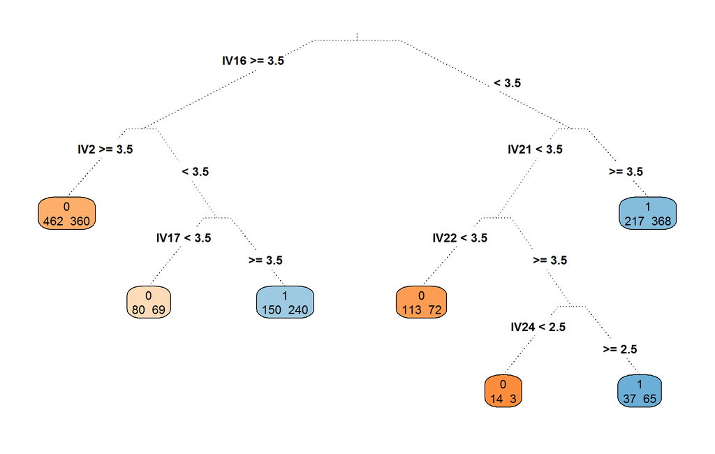

After also running the large tree and the logistic regression classifiers, we can then check how much “weight” these three methods put on the different purchase drivers (Q16 of the survey):

|  | CART 1 | CART 2 | Logistic Regr. |
| --- | --- | --- | --- |
| Q16.1 | 0.00000000 | 0.011019687 | 0.09090909 |
| Q16.2 | -1.00000000 | -0.899454252 | -0.77272727 |
| Q16.3 | 0.17810761 | 0.399446101 | 0.04545455 |
| Q16.4 | -0.27298417 | -0.765357150 | -0.20454545 |
| Q16.5 | 0.19480519 | 0.657793803 | 0.25000000 |
| Q16.6 | -0.13206483 | -0.103951708 | -0.29545455 |
| Q16.7 | 0.00000000 | -0.054540259 | -0.02272727 |
| Q16.8 | 0.07231261 | 0.658198414 | 0.40909091 |
| Q16.9 | 0.00000000 | 0.005692312 | 0.47727273 |
| Q16.10 | 0.00000000 | 0.491786085 | 0.75000000 |
| Q16.11 | -0.32096475 | -0.230192726 | -0.45454545 |
| Q16.12 | 0.14048073 | 0.736723792 | 0.72727273 |
| Q16.13 | -0.15083876 | -0.335896900 | -0.54545455 |
| Q16.14 | -0.21363429 | -0.202656708 | -0.31818182 |
| Q16.15 | 0.13400696 | 0.096108462 | 0.29545455 |
| Q16.16 | -0.57551783 | -0.640472508 | -1.00000000 |
| Q16.17 | -0.50419287 | -0.846807210 | -0.38636364 |
| Q16.18 | -0.09940166 | -0.404064789 | -0.22727273 |
| Q16.19 | 0.28629241 | 0.297394573 | 0.40909091 |
| Q16.20 | 0.26520309 | 0.299989042 | 0.06818182 |
| Q16.21 | 0.95306972 | 1.000000000 | 0.50000000 |
| Q16.22 | 0.62914386 | 0.739418001 | 0.20454545 |
| Q16.23 | -0.43657168 | -0.412043025 | -0.11363636 |
| Q16.24 | 0.51894572 | 0.372182710 | 0.34090909 |
| Q16.25 | -0.17068646 | -0.938098365 | -0.25000000 |
| Q16.26 | 0.34208441 | 0.245339536 | 0.36363636 |
| Q16.27 | 0.00000000 | 0.719935467 | 0.40909091 |

Finally, if we were to use the estimated classification models on the test data, we would get the following profit curves (see the raw .Rmd file to select the business profit parameters).

The profit curve using the small classification tree:

[interactive chart not shown]

The profit curve using the large classification tree:

[interactive chart not shown]

The profit curve using the logistic regression classifier:

[interactive chart not shown]

These are the maximum total profit achieved in the test data using the three classifiers (without any segment specific analysis so far).

|  | Percentile | Profit |
| --- | --- | --- |
| Small Tree | 100.00 | 4650 |
| Large Tree | 95.04 | 4675 |
| Logistic Regression | 98.58 | 4850 |

# Part 4: Business Decisions

We will now get the results of the overall process (parts 1-3) and based on them make business decisions (e.g. answer the questions of the Boats case study). Specifically, we will study the purchase drivers for each segment we found and consider the profit curves of the developed models on our test data.

**Final Solution: Segment Specific Analysis**

Let’s see first how many observations we have in each segment, for the segments we selected above:

|  | Segment 1 | Segment 2 | Segment 3 | Segment 4 |
| --- | --- | --- | --- | --- |
| Number of Obs. | 830 | 319 | 858 | 806 |

|  | Segment 1 | Segment 2 | Segment 3 | Segment 4 |
| --- | --- | --- | --- | --- |
| Q16.2 | -0.52 | 0.04 | -0.73 | -0.39 |
| Q16.3 | 0.23 | 0.11 | 0.21 | -0.15 |
| Q16.4 | 0.06 | -0.70 | -0.18 | -0.06 |
| Q16.5 | 0.26 | 0.70 | 0.03 | 0.09 |
| Q16.6 | -0.23 | -0.22 | -0.15 | -0.09 |
| Q16.7 | -0.13 | 0.56 | -0.12 | -0.18 |
| Q16.8 | 0.00 | -0.22 | 0.27 | 1.00 |
| Q16.9 | 0.74 | 0.19 | 0.18 | 0.18 |
| Q16.10 | 0.77 | -0.15 | 0.33 | 0.42 |
| Q16.11 | -0.52 | 0.37 | -0.06 | -0.48 |
| Q16.12 | 1.00 | 0.41 | 0.48 | 0.09 |
| Q16.13 | -0.77 | 0.07 | -0.36 | 0.00 |
| Q16.14 | -0.23 | -1.00 | -0.12 | -0.24 |
| Q16.15 | 0.10 | 0.85 | 0.30 | 0.09 |
| Q16.16 | -0.71 | 0.07 | -0.73 | -0.70 |
| Q16.17 | -0.61 | -0.48 | -0.15 | 0.39 |
| Q16.18 | -0.61 | 0.33 | 0.21 | -0.33 |
| Q16.19 | 0.87 | -0.37 | 0.15 | 0.00 |
| Q16.20 | -0.16 | 0.11 | 0.58 | -0.06 |
| Q16.21 | 0.03 | 0.30 | 0.61 | 0.42 |
| Q16.22 | -0.19 | 0.04 | 0.42 | 0.52 |
| Q16.23 | 0.39 | 0.56 | -1.00 | 0.09 |
| Q16.24 | 0.03 | 0.63 | 0.42 | 0.52 |
| Q16.25 | 0.10 | -0.70 | -0.18 | 0.33 |
| Q16.26 | 0.48 | 0.00 | -0.03 | 0.55 |
| Q16.27 | 0.68 | -0.11 | 0.64 | 0.48 |

The profit curves for the test data in this case are as follows. The profit curve using the small classification tree is:

[interactive chart not shown]

The profit curve using the large classification tree is:

[interactive chart not shown]

The profit curve using the logistic regression classifier:

[interactive chart not shown]

These are the maximum total profit achieved in the test data using the three classifiers with the selected market segmentation solution.

|  | Percentile | Profit |
| --- | --- | --- |
| Small Tree | 93.97 | 4825 |
| Large Tree | 93.97 | 4825 |
| Logistic Regression | 100.00 | 4650 |

**Questions:**

1. What are the main purchase drivers for the segments and solution you found?
2. How different are the purchase drivers you find when you use segmentation versus when you study all customers as “one segment”? Why?
3. Based on the overall analysis, what segmentation would you choose?
4. What is the business profit the company can achieve (as measured with the test data) based on your solution?
5. What business decisions can the company make based on this analysis?

**Answers:**

**You have now completed your first market segmentation project.** Do you have data from another survey you can use with this report now?

**Extra question**: explore and report a new segmentation analysis…